# Risk Factor Analysis

## Outcome Variable

**Outcome Variable:** haz

## Predictor Variables

**Intervention Variable:** country

**Adjustment Set:**

unadjusted

## Stratifying Variables

The analysis was stratified on these variable(s):

- agecat

## Data Summary

| agecat | country | n_cell | n | outcome_variable |
| --- | --- | --- | --- | --- |
| Birth | BANGLADESH | 27414 | 70599 | haz |
| Birth | BELARUS | 13893 | 70599 | haz |
| Birth | BRAZIL | 65 | 70599 | haz |
| Birth | GAMBIA | 1543 | 70599 | haz |
| Birth | GUATEMALA | 852 | 70599 | haz |
| Birth | INDIA | 8419 | 70599 | haz |
| Birth | MALAWI | 0 | 70599 | haz |
| Birth | NEPAL | 723 | 70599 | haz |
| Birth | PAKISTAN | 282 | 70599 | haz |
| Birth | PERU | 235 | 70599 | haz |
| Birth | PHILIPPINES | 3050 | 70599 | haz |
| Birth | SOUTH AFRICA | 123 | 70599 | haz |
| Birth | TANZANIA, UNITED REPUBLIC OF | 125 | 70599 | haz |
| Birth | ZIMBABWE | 13875 | 70599 | haz |
| 6 months | BANGLADESH | 23982 | 69534 | haz |
| 6 months | BELARUS | 15760 | 69534 | haz |
| 6 months | BRAZIL | 209 | 69534 | haz |
| 6 months | GAMBIA | 2089 | 69534 | haz |
| 6 months | GUATEMALA | 1260 | 69534 | haz |
| 6 months | INDIA | 9588 | 69534 | haz |
| 6 months | MALAWI | 839 | 69534 | haz |
| 6 months | NEPAL | 800 | 69534 | haz |
| 6 months | PAKISTAN | 612 | 69534 | haz |
| 6 months | PERU | 488 | 69534 | haz |
| 6 months | PHILIPPINES | 2708 | 69534 | haz |
| 6 months | SOUTH AFRICA | 254 | 69534 | haz |
| 6 months | TANZANIA, UNITED REPUBLIC OF | 2276 | 69534 | haz |
| 6 months | ZIMBABWE | 8669 | 69534 | haz |
| 24 months | BANGLADESH | 15359 | 35072 | haz |
| 24 months | BELARUS | 4035 | 35072 | haz |
| 24 months | BRAZIL | 169 | 35072 | haz |
| 24 months | GAMBIA | 1725 | 35072 | haz |
| 24 months | GUATEMALA | 1070 | 35072 | haz |
| 24 months | INDIA | 6344 | 35072 | haz |
| 24 months | MALAWI | 579 | 35072 | haz |
| 24 months | NEPAL | 716 | 35072 | haz |
| 24 months | PAKISTAN | 167 | 35072 | haz |
| 24 months | PERU | 365 | 35072 | haz |
| 24 months | PHILIPPINES | 2445 | 35072 | haz |
| 24 months | SOUTH AFRICA | 238 | 35072 | haz |
| 24 months | TANZANIA, UNITED REPUBLIC OF | 220 | 35072 | haz |
| 24 months | ZIMBABWE | 1640 | 35072 | haz |

The following strata were considered:

- agecat: 24 months
- agecat: 6 months
- agecat: Birth

### Dropped Strata

Some strata were dropped due to rare outcomes:

- agecat: Birth

## Methods Detail

We’re interested in the causal parameters $E[Y_a]$ for all values of $a \in \mathcal{A}$. These parameters represent the mean outcome if, possibly contrary to fact, we intervened to set all units to have $A=a$. Under the randomization and positivity assumptions, these are identified by the statistical parameters $\psi_a=E_W[E_{Y|A,W}(Y|A=a,W)]$. In addition, we’re interested in the mean of $Y$, $E[Y]$ under no intervention (the observed mean). We will estimate these parameters by using SuperLearner to fit the relevant likelihood factors – $E_{Y|A,W}(Y|A=a,W)$ and $p(A=a|W)$, and then updating our likelihood fit using a joint TMLE.

For unadjusted analyses ($W=\{\}$), initial likelihoods were estimated using Lrnr_glm to estimate the simple $E(Y|A)$ and Lrnr_mean to estimate $p(A)$. For adjusted analyses, a small library containing Lrnr_glmnet, Lrnr_xgboost, and Lrnr_mean was used.

Having estimated these parameters, we will then use the delta method to estimate relative risks and attributable risks relative to a prespecified baseline level of $A$.

# Results Detail

## Results Plots

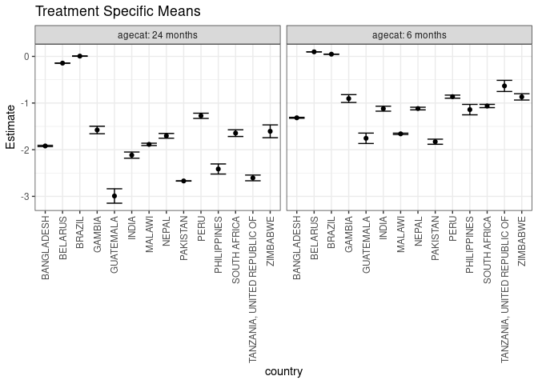

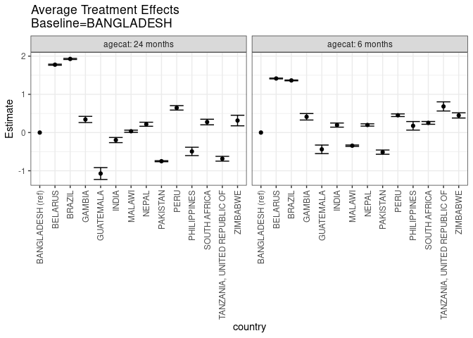

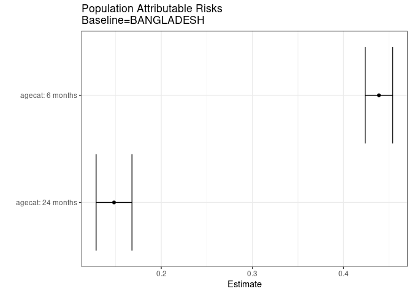

## Results Table

### Parameter: TSM

| agecat | intervention_level | baseline_level | estimate | ci_lower | ci_upper |
| --- | --- | --- | --- | --- | --- |
| 6 months | BANGLADESH | NA | -1.3162927 | -1.3261389 | -1.3064465 |
| 6 months | BELARUS | NA | 0.0980074 | 0.0976001 | 0.0984147 |
| 6 months | BRAZIL | NA | 0.0475758 | 0.0464206 | 0.0487309 |
| 6 months | GAMBIA | NA | -0.9041369 | -0.9882027 | -0.8200712 |
| 6 months | GUATEMALA | NA | -1.7554987 | -1.8668164 | -1.6441809 |
| 6 months | INDIA | NA | -1.1208090 | -1.1740921 | -1.0675259 |
| 6 months | MALAWI | NA | -1.6601907 | -1.6750280 | -1.6453534 |
| 6 months | NEPAL | NA | -1.1180083 | -1.1462464 | -1.0897703 |
| 6 months | PAKISTAN | NA | -1.8288780 | -1.8836433 | -1.7741127 |
| 6 months | PERU | NA | -0.8632046 | -0.8959582 | -0.8304509 |
| 6 months | PHILIPPINES | NA | -1.1405724 | -1.2523969 | -1.0287478 |
| 6 months | SOUTH AFRICA | NA | -1.0633202 | -1.0983688 | -1.0282717 |
| 6 months | TANZANIA, UNITED REPUBLIC OF | NA | -0.6330042 | -0.7524105 | -0.5135979 |
| 6 months | ZIMBABWE | NA | -0.8679450 | -0.9355882 | -0.8003017 |
| 24 months | BANGLADESH | NA | -1.9200375 | -1.9340456 | -1.9060294 |
| 24 months | BELARUS | NA | -0.1442891 | -0.1467764 | -0.1418019 |
| 24 months | BRAZIL | NA | 0.0061144 | 0.0025689 | 0.0096599 |
| 24 months | GAMBIA | NA | -1.5774356 | -1.6576005 | -1.4972706 |
| 24 months | GUATEMALA | NA | -2.9923738 | -3.1472124 | -2.8375353 |
| 24 months | INDIA | NA | -2.1164384 | -2.1827127 | -2.0501640 |
| 24 months | MALAWI | NA | -1.8861485 | -1.9106757 | -1.8616214 |
| 24 months | NEPAL | NA | -1.7027793 | -1.7540208 | -1.6515379 |
| 24 months | PAKISTAN | NA | -2.6699900 | -2.6726275 | -2.6673525 |
| 24 months | PERU | NA | -1.2736758 | -1.3300343 | -1.2173173 |
| 24 months | PHILIPPINES | NA | -2.4141145 | -2.5225767 | -2.3056524 |
| 24 months | SOUTH AFRICA | NA | -1.6450595 | -1.7169127 | -1.5732064 |
| 24 months | TANZANIA, UNITED REPUBLIC OF | NA | -2.6051818 | -2.6662274 | -2.5441363 |
| 24 months | ZIMBABWE | NA | -1.6055701 | -1.7429703 | -1.4681700 |

### Parameter: E(Y)

| agecat | intervention_level | baseline_level | estimate | ci_lower | ci_upper |
| --- | --- | --- | --- | --- | --- |
| 6 months | NA | NA | -0.877431 | -0.8914874 | -0.8633747 |
| 24 months | NA | NA | -1.771869 | -1.7910003 | -1.7527377 |

### Parameter: ATE

| agecat | intervention_level | baseline_level | estimate | ci_lower | ci_upper |
| --- | --- | --- | --- | --- | --- |
| 6 months | BANGLADESH | BANGLADESH | 0.0000000 | 0.0000000 | 0.0000000 |
| 6 months | BELARUS | BANGLADESH | 1.4143001 | 1.4044454 | 1.4241549 |
| 6 months | BRAZIL | BANGLADESH | 1.3638685 | 1.3539556 | 1.3737814 |
| 6 months | GAMBIA | BANGLADESH | 0.4121558 | 0.3275176 | 0.4967941 |
| 6 months | GUATEMALA | BANGLADESH | -0.4392059 | -0.5509446 | -0.3274673 |
| 6 months | INDIA | BANGLADESH | 0.1954837 | 0.1412948 | 0.2496727 |
| 6 months | MALAWI | BANGLADESH | -0.3438980 | -0.3617063 | -0.3260896 |
| 6 months | NEPAL | BANGLADESH | 0.1982844 | 0.1683797 | 0.2281891 |
| 6 months | PAKISTAN | BANGLADESH | -0.5125853 | -0.5682325 | -0.4569380 |
| 6 months | PERU | BANGLADESH | 0.4530882 | 0.4188828 | 0.4872936 |
| 6 months | PHILIPPINES | BANGLADESH | 0.1757204 | 0.0634632 | 0.2879775 |
| 6 months | SOUTH AFRICA | BANGLADESH | 0.2529725 | 0.2165719 | 0.2893731 |
| 6 months | TANZANIA, UNITED REPUBLIC OF | BANGLADESH | 0.6832886 | 0.5634652 | 0.8031120 |
| 6 months | ZIMBABWE | BANGLADESH | 0.4483478 | 0.3799935 | 0.5167020 |
| 24 months | BANGLADESH | BANGLADESH | 0.0000000 | 0.0000000 | 0.0000000 |
| 24 months | BELARUS | BANGLADESH | 1.7757484 | 1.7615228 | 1.7899740 |
| 24 months | BRAZIL | BANGLADESH | 1.9261519 | 1.9117059 | 1.9405978 |
| 24 months | GAMBIA | BANGLADESH | 0.3426019 | 0.2612318 | 0.4239720 |
| 24 months | GUATEMALA | BANGLADESH | -1.0723363 | -1.2278072 | -0.9168655 |
| 24 months | INDIA | BANGLADESH | -0.1964009 | -0.2641380 | -0.1286637 |
| 24 months | MALAWI | BANGLADESH | 0.0338890 | 0.0056428 | 0.0621351 |
| 24 months | NEPAL | BANGLADESH | 0.2172582 | 0.1641355 | 0.2703808 |
| 24 months | PAKISTAN | BANGLADESH | -0.7499525 | -0.7641952 | -0.7357098 |
| 24 months | PERU | BANGLADESH | 0.6463617 | 0.5883075 | 0.7044159 |
| 24 months | PHILIPPINES | BANGLADESH | -0.4940770 | -0.6034400 | -0.3847140 |
| 24 months | SOUTH AFRICA | BANGLADESH | 0.2749780 | 0.2017895 | 0.3481664 |
| 24 months | TANZANIA, UNITED REPUBLIC OF | BANGLADESH | -0.6851443 | -0.7477638 | -0.6225248 |
| 24 months | ZIMBABWE | BANGLADESH | 0.3144674 | 0.1763570 | 0.4525777 |

### Parameter: PAR

| agecat | intervention_level | baseline_level | estimate | ci_lower | ci_upper |
| --- | --- | --- | --- | --- | --- |
| 6 months | BANGLADESH | NA | 0.4388617 | 0.4237653 | 0.4539582 |
| 24 months | BANGLADESH | NA | 0.1481685 | 0.1284736 | 0.1678633 |